# Module2_final

```python
import datashader as ds
import datashader.transfer_functions as tf
import datashader.glyphs
from datashader import reductions
from datashader.core import bypixel
from datashader.utils import lnglat_to_meters as webm, export_image
from datashader.colors import colormap_select, Greys9, viridis, inferno
# Add DataShader and Jupyter view utilities
from datashader.colors import colormap_select, Greys9
# Add DataShader Legend support
from bokeh.io import output_notebook, show
from datashader.bokeh_ext import create_categorical_legend

import copy

from pyproj import Proj, transform
import numpy as np
import pandas as pd
import urllib
import json
import datetime
import colorlover as cl


# Alter imports to the more familiar optimize performance
#import plotly.offline as py
import chart_studio.plotly as py
#import plotly.graph_objs as go
import plotly.graph_objects as go
from plotly import tools
import plotly.express as px

from IPython.display import Image

from shapely.geometry import Point, Polygon, shape
# In order to get shapley, you'll need to run [pip install shapely.geometry] from your terminal

from functools import partial

from IPython.display import GeoJSON
# Added
#from IPython.core.display import HTML, display

# Alter imports to the more familiar optimize performance
#py.init_notebook_mode()

# Add data exploration utilities
import matplotlib.pyplot as plt
from scipy import stats
```

For module 2 we'll be looking at techniques for dealing with big data. In particular binning strategies and the datashader library (which possibly proves we'll never need to bin large data for visualization ever again.)

To demonstrate these concepts we'll be looking at the PLUTO dataset put out by New York City's department of city planning. PLUTO contains data about every tax lot in New York City.

PLUTO data can be downloaded from [here](https://www1.nyc.gov/site/planning/data-maps/open-data/dwn-pluto-mappluto.page). Unzip them to the same directory as this notebook, and you should be able to read them in using this (or very similar) code. Also take note of the data dictionary, it'll come in handy for this assignment.

```python
# Code to read in v17, column names have been updated (without upper case letters) for v18

# bk = pd.read_csv('PLUTO17v1.1/BK2017V11.csv')
# bx = pd.read_csv('PLUTO17v1.1/BX2017V11.csv')
# mn = pd.read_csv('PLUTO17v1.1/MN2017V11.csv')
# qn = pd.read_csv('PLUTO17v1.1/QN2017V11.csv')
# si = pd.read_csv('PLUTO17v1.1/SI2017V11.csv')

# ny = pd.concat([bk, bx, mn, qn, si], ignore_index=True)

ny = pd.read_csv('nyc_pluto_20v1_csv/pluto_20v1.csv')
#  DtypeWarning:Columns (17,18,20,22) have mixed types.Specify dtype option on import or set low_memory=False.
# To get rigd of error https://github.com/plotly/dash-oil-and-gas-demo/issues/4
#ny = pd.read_csv('nyc_pluto_20v1_csv/pluto_20v1.csv', index_col=None, na_values=['NA'], sep=',',low_memory=False)


# Getting rid of some outliers
ny = ny[(ny['yearbuilt'] > 1850) & (ny['yearbuilt'] < 2020) & (ny['numfloors'] != 0)]
```

I'll also do some prep for the geographic component of this data, which we'll be relying on for datashader.

You're not required to know how I'm retrieving the lattitude and longitude here, but for those interested: this dataset uses a flat x-y projection (assuming for a small enough area that the world is flat for easier calculations), and this needs to be projected back to traditional lattitude and longitude.

```python
# wgs84 = Proj('+proj=longlat +ellps=GRS80 +datum=NAD83 +no_defs')
# nyli = Proj('+proj=lcc +lat_1=40.66666666666666 +lat_2=41.03333333333333 +lat_0=40.16666666666666 +lon_0=-74 +x_0=300000 +y_0=0 +ellps=GRS80 +datum=NAD83 +to_meter=0.3048006096012192 +no_defs')
# ny['xcoord'] = 0.3048*ny['xcoord']
# ny['ycoord'] = 0.3048*ny['ycoord']
# ny['lon'], ny['lat'] = transform(nyli, wgs84, ny['xcoord'].values, ny['ycoord'].values)

# ny = ny[(ny['lon'] < -60) & (ny['lon'] > -100) & (ny['lat'] < 60) & (ny['lat'] > 20)]

#Defining some helper functions for DataShader
background = 'black'
export = partial(export_image, background = background, export_path='export')
cm = partial(colormap_select, reverse=(background!='black'))
```

## Part 1: Binning and Aggregation

Binning is a common strategy for visualizing large datasets. Binning is inherent to a few types of visualizations, such as histograms and [2D histograms](https://plot.ly/python/2D-Histogram/) (also check out their close relatives: [2D density plots](https://plot.ly/python/2d-density-plots/) and the more general form: [heatmaps](https://plot.ly/python/heatmaps/).

While these visualization types explicitly include binning, any type of visualization used with aggregated data can be looked at in the same way. For example, lets say we wanted to look at building construction over time. This would be best viewed as a line graph, but we can still think of our results as being binned by year:

```python
trace = go.Scatter(
    # I'm choosing BBL here because I know it's a unique key.
    x = ny.groupby('yearbuilt').count()['bbl'].index,
    y = ny.groupby('yearbuilt').count()['bbl']
)

layout = go.Layout(
    xaxis = dict(title = 'Year Built'),
    yaxis = dict(title = 'Number of Lots Built')
)

fig = go.FigureWidget(data = [trace], layout = layout)

fig
```

[output not shown]

But first: some notes on pandas. Pandas dataframes are a different beast than R dataframes, here are some tips to help you get up to speed:

Hello all, here are some pandas tips to help you guys through this homework:

[Indexing and Selecting](https://pandas.pydata.org/pandas-docs/stable/indexing.html): .loc and .iloc are the analogs for base R subsetting, or filter() in dplyr

[Group By](https://pandas.pydata.org/pandas-docs/stable/groupby.html): This is the pandas analog to group_by() and the appended function the analog to summarize(). Try out a few examples of this, and display the results in Jupyter. Take note of what's happening to the indexes, you'll notice that they'll become hierarchical. I personally find this more of a burden than a help, and this sort of hierarchical indexing leads to a fundamentally different experience compared to R dataframes. Once you perform an aggregation, try running the resulting hierarchical datafrome through a [reset_index()](https://pandas.pydata.org/pandas-docs/stable/generated/pandas.DataFrame.reset_index.html).

[Reset_index](https://pandas.pydata.org/pandas-docs/stable/generated/pandas.DataFrame.reset_index.html): I personally find the hierarchical indexes more of a burden than a help, and this sort of hierarchical indexing leads to a fundamentally different experience compared to R dataframes. reset_index() is a way of restoring a dataframe to a flatter index style. Grouping is where you'll notice it the most, but it's also useful when you filter data, and in a few other split-apply-combine workflows. With pandas indexes are more meaningful, so use this if you start getting unexpected results.

Indexes are more important in Pandas than in R. If you delve deeper into the using python for data science, you'll begin to see the benefits in many places (despite the personal gripes I highlighted above.) One place these indexes come in handy is with time series data. The pandas docs have a [huge section](http://pandas.pydata.org/pandas-docs/stable/timeseries.html) on datetime indexing. In particular, check out [resample](https://pandas.pydata.org/pandas-docs/stable/generated/pandas.DataFrame.resample.html), which provides time series specific aggregation.

[Merging, joining, and concatenation](https://pandas.pydata.org/pandas-docs/stable/merging.html): There's some overlap between these different types of merges, so use this as your guide. Concat is a single function that replaces cbind and rbind in R, and the results are driven by the indexes. Read through these examples to get a feel on how these are performed, but you will have to manage your indexes when you're using these functions. Merges are fairly similar to merges in R, similarly mapping to SQL joins.

Apply: This is explained in the 'group by' section linked above. These are your analogs to the plyr library in R. Take note of the lambda syntax used here, these are anonymous functions in python. Rather than predefining a custom function, you can just define it inline using lambda.

Browse through the other sections for some other specifics, in particular reshaping and categorical data (pandas' answer to factors.) Pandas can take a while to get used to, but it is a pretty strong framework that makes more advanced functions easier once you get used to it. Rolling functions for example follow logically from the apply workflow (and led to the best google results ever when I first tried to find this out and googled 'pandas rolling')

Google Wes Mckinney's book 'Python for Data Analysis,' which is a cookbook style intro to pandas. It's an O'Reilly book that should be pretty available out there.

### Question

After a few building collapses, the City of New York is going to begin investigating older buildings for safety. The city is particularly worried about buildings that were unusually tall when they were built, since best-practices for safety hadn’t yet been determined. Create a graph that shows how many buildings of a certain number of floors were built in each year (note: you may want to use a log scale for the number of buildings). Find a strategy to bin buildings (It should be clear 20-29-story buildings, 30-39-story buildings, and 40-49-story buildings were first built in large numbers, but does it make sense to continue in this way as you get taller?)

```python
# Start your answer here, inserting more cells as you go along
```

#### View first 5 rows of data

```python
#  Remove bracket autoclose
#from notebook.services.config import ConfigManager
#c = ConfigManager()
#c.update('notebook', {'CodeCell': {'cm_config': {'autoCloseBrackets': False}}})

ny_head = ny.head()
ny_head
```

|  | borough | block | lot | cd | ct2010 | cb2010 | schooldist | council | zipcode | firecomp | ... | dcasdate | zoningdate | landmkdate | basempdate | masdate | polidate | edesigdate | geom | dcpedited | notes |
| --- | --- | --- | --- | --- | --- | --- | --- | --- | --- | --- | --- | --- | --- | --- | --- | --- | --- | --- | --- | --- | --- |
| 0 | BK | 834 | 46 | 307.0 | 106.0 | 2001.0 | 20.0 | 38.0 | 11220.0 | L114 | ... | NaN | NaN | NaN | NaN | NaN | NaN | NaN | 0106000020E61000000100000001030000000100000005... | NaN | NaN |
| 1 | QN | 4042 | 106 | 407.0 | 929.0 | 3000.0 | 25.0 | 19.0 | 11356.0 | E297 | ... | NaN | NaN | NaN | NaN | NaN | NaN | NaN | 0106000020E61000000100000001030000000100000007... | NaN | NaN |
| 2 | BK | 4679 | 17 | 317.0 | 866.0 | 3002.0 | 18.0 | 41.0 | 11203.0 | L174 | ... | NaN | NaN | NaN | NaN | NaN | NaN | NaN | 0106000020E61000000100000001030000000100000006... | NaN | NaN |
| 3 | BK | 7831 | 6 | 318.0 | 676.0 | 1002.0 | 22.0 | 46.0 | 11234.0 | L159 | ... | NaN | NaN | NaN | NaN | NaN | NaN | NaN | 0106000020E61000000100000001030000000100000005... | NaN | NaN |
| 4 | BK | 7831 | 7 | 318.0 | 676.0 | 1002.0 | 22.0 | 46.0 | 11234.0 | L159 | ... | NaN | NaN | NaN | NaN | NaN | NaN | NaN | 0106000020E61000000100000001030000000100000005... | NaN | NaN |

5 rows × 99 columns

#### View all column names

```python
# Un/comment
for x in sorted(['{0: <20}'.format(c)+str(ny_head.iloc[0,i]) for i, c in enumerate(ny_head.columns)]):
    print(x)
```

```
address             5524 8 AVENUE
appbbl              nan
appdate             nan
areasource          2.0
assessland          146250.0
assesstot           350550.0
basempdate          nan
bbl                 3008340046
bldgarea            3648.0
bldgclass           S9
bldgdepth           52.0
bldgfront           20.17
block               834
borocode            3
borough             BK
bsmtcode            5.0
builtfar            2.26
cb2010              2001.0
cd                  307.0
comarea             1050.0
commfar             0.0
condono             nan
council             38.0
ct2010              106.0
dcasdate            nan
dcpedited           nan
easements           0.0
edesigdate          nan
edesignum           nan
exempttot           0.0
ext                 E
facilfar            4.8
factryarea          0.0
firecomp            L114
firm07_flag         nan
garagearea          0.0
geom                0106000020E61000000100000001030000000100000005000000E3545CD1…
healtharea          6700.0
healthcenterdistrict39.0
histdist            nan
```

[output cut: 44 more lines]

```
unitstotal          4.0
version             20v1
xcoord              982211.0
ycoord              171707.0
yearalter1          0.0
yearalter2          0.0
yearbuilt           1931.0
zipcode             11220.0
zmcode              nan
zonedist1           R6
zonedist2           nan
zonedist3           nan
zonedist4           nan
zonemap             22a
zoningdate          nan
```

#### Copy and transform data

Note the following research on the number of floors: 'A NYC tax lot uses Borough Block and Lot (BBL) as a unique parcel identifier. DCP compiles a variety of City data sets at the parcel level into MapPluto. One of the main data sources is the Department of Finance’s (DOF) Real Property and Assessment Data (RPAD). One of the attributes in RPAD is Number of floors, which is included in MapPluto as NumFloors. DCP defines this column in the metadata as being for “…the primary building on the tax lot, the number of full and partial stories starting from the ground floor.” This is due to the fact, as previously stated, that there can be multiple buildings on a tax lot. Since only one value is possible, DCP elected to go with the number of floors of the ‘primary’ building.'

https://nycitymap.wordpress.com/2014/12/12/nyc-building-footprints/

```python
# Build DataFrame with needed data
data = {
    'year_built': pd.to_datetime(ny['yearbuilt'].copy(deep=True).astype(str),format='%Y%m%d',errors='ignore'),
    'decade_built': ny['yearbuilt'].copy(deep=True).astype(int)//10*10,
    'num_floors' : ny['numfloors'].copy(deep=True),
    'bbl' : ny['bbl'].copy(deep=True)
}

df = pd.DataFrame(data)

# Create a log of the floors for each decade
df['decade_floor_log'] = df.groupby('decade_built')['num_floors'].apply(lambda x: np.log(x))

# ny_floors = ny_floors.set_index(pd.DatetimeIndex(pd.to_datetime(ny['yearbuilt'],format='%Y%m%d',errors='ignore')).date)

df.head()
```

|  | year_built | decade_built | num_floors | bbl | decade_floor_log |
| --- | --- | --- | --- | --- | --- |
| 0 | 1931.0 | 1930 | 3.00 | 3008340046 | 1.098612 |
| 1 | 1910.0 | 1910 | 2.75 | 4040420106 | 1.011601 |
| 2 | 1920.0 | 1920 | 2.00 | 3046790017 | 0.693147 |
| 3 | 1920.0 | 1920 | 2.00 | 3078310006 | 0.693147 |
| 4 | 1920.0 | 1920 | 2.00 | 3078310007 | 0.693147 |

#### Duplicated values

```python
df[df['bbl'].duplicated()]
```

|  | year_built | decade_built | num_floors | bbl | decade_floor_log |
| --- | --- | --- | --- | --- | --- |

#### Null and Zero Values

```python
df.isnull().sum().sum() + df.isna().sum().sum() != 0
```

```
False
```

#### Violin Plot

While tempted to create a distplot, ridgeline or heatmap, I've opted to use violin plots and a manually calculated log per decade to reduce the complexity and perhaps memory needed for the graph.

```python
# Use voilin plot to preserve point data and distribution data per decade
fig1 = px.violin(df.sort_values(by=['decade_built']),
                y='decade_floor_log',
                x='year_built',
                color='decade_built',
                box=True,
                hover_data=df.columns)

fig1.update_layout(
    title_text='Distribution of NYC Building Floors by Decade',
    xaxis=dict(title_text='Year Built'),
    yaxis=dict(title_text='Floor Count Distribution')
)

print('')
```

##### Interact with the Violin plot to examine outliers

```python
# Uncomment to interact with outlier data point
#fig1.show()
```

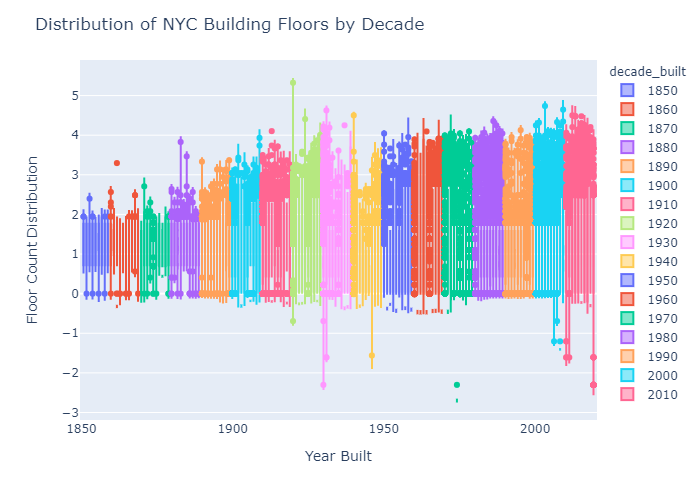

```python
# Save as image to reduce memory
fig1.write_image('fig1.png')
Image('fig1.png')
```

#### Further exploration

Adding the lines showing the distribution of real floor counts or average counts to the above graph could improve the Violin chart (not done except as an interactive feature). The box plots don't appear to show well in the Violin chart either. This could be fixed by adding breakout charts (not done). We can also bin the number of floors by examining the boxplot data in the describe() function or by using our log calculation above. Using log axis functions aren't easily visible with this much data, so we continue to use our log cuts.

```python
decades = sorted(df['decade_built'].unique())

print('All years',decades[0],'-',decades[-1],':\n', df['num_floors'].describe())
for decade in decades:
    print('\n', 'Decade:', decade)
    print(df[df['decade_built']==decade]['num_floors'].describe())
```

```
All years 1850 - 2010 :
 count    811684.000000
mean          2.457334
std           1.982234
min           0.100000
25%           2.000000
50%           2.000000
75%           2.500000
max         205.000000
Name: num_floors, dtype: float64

 Decade: 1850
count    1555.000000
mean        3.537460
std         0.919151
min         1.000000
25%         3.000000
50%         3.000000
75%         4.000000
max        11.000000
Name: num_floors, dtype: float64

 Decade: 1860
count    1548.000000
mean        3.615956
std         1.262894
min         1.000000
25%         3.000000
50%         3.000000
75%         4.000000
max        27.000000
Name: num_floors, dtype: float64

 Decade: 1870
count    2736.000000
mean        3.377741
std         1.082093
min         1.000000
25%         3.000000
50%         3.000000
```

[output cut: 142 more lines]

```
50%          2.000000
75%          3.000000
max        114.000000
Name: num_floors, dtype: float64

 Decade: 2010
count    15143.000000
mean         4.218381
std          5.751172
min          0.100000
25%          2.000000
50%          3.000000
75%          4.000000
max         90.000000
Name: num_floors, dtype: float64
```

#### New distribution-based binnning approach

During the course of implementing log-based breaks, however, I came across an article which compares quartile computations performed through cut or qcut functions to a library-based grouping approach, jenkspy, which I thought would be ideal for answering this question, the details of which can be found at https://pbpython.com/natural-breaks.html and which follow. The techniques recommended both failed to product enough quantile cuts for our spec, even when applied to decades, so we moved back to the simple logarithmic calculation as a starting point in identifying groups which might contain our known positives.

Given known observations of dangerous buildings, the experts can focus in on the outliers seen in the overview below or even filter with log_cuts or a more appropriate normalization method for exploting outlier. Our features give flexiblity to explore, update, and visualize the data in meaningful and understandable ways.

```python
# Not working
#import jenkspy
#df['cut_jenks'] = pd.cut(
#    df['num_floors'],
#    bins=jenkspy.jenks_breaks(df['num_floors'].values.tolist(), nb_class=2),
#    duplicates='drop',
#    labels=['bucket_1', 'bucket_2'],
#    include_lowest=True)

# In this case loc is working with qcut to automatically calculate quantiles,
# but it fails to process more than 2 in each decade.
# https://pandas.pydata.org/pandas-docs/stable/user_guide/indexing.html#returning-a-view-versus-a-copy
nquant = 2
for decade in decades:
    df.loc[df['decade_built']==decade,'q_cut'] = pd.qcut(
        df[df['decade_built']==decade]['num_floors'].values,
        q=nquant,
        labels=['cut_'+str(i) for i in range(nquant)],
        duplicates='drop')

# Make cuts by flooring the per-decade logorithmic value.
df['log_cut'] = df['decade_floor_log'] // 1
log_min = df['log_cut'].min()
df['log_cut'] = df['log_cut']+log_min*-1
df['log_cut'] = df['log_cut'].astype('str').apply(lambda x: 'cut_'+x[:-2])

df.head()
```

|  | year_built | decade_built | num_floors | bbl | decade_floor_log | q_cut | log_cut |
| --- | --- | --- | --- | --- | --- | --- | --- |
| 0 | 1931.0 | 1930 | 3.00 | 3008340046 | 1.098612 | cut_1 | cut_4 |
| 1 | 1910.0 | 1910 | 2.75 | 4040420106 | 1.011601 | cut_1 | cut_4 |
| 2 | 1920.0 | 1920 | 2.00 | 3046790017 | 0.693147 | cut_0 | cut_3 |
| 3 | 1920.0 | 1920 | 2.00 | 3078310006 | 0.693147 | cut_0 | cut_3 |
| 4 | 1920.0 | 1920 | 2.00 | 3078310007 | 0.693147 | cut_0 | cut_3 |

#### Exploring distributions by cut per decade

While a distplot is more intuitive here, the histogram is easier to see and interact with. An expert should focus on graphing the cuts they are interested in using similar techniques.

```python
fig2 = px.histogram(df.sort_values(by=['year_built']),
    x='log_cut',
    color='log_cut',
    facet_row='decade_built',
    width=1000, height=4200,
    category_orders={'log_cut': ['cut_0', 'cut_1', 'cut_2', 'cut_3', 'cut_4', 'cut_5', 'cut_6', 'cut_7']},
    hover_data=df.columns)

fig2.update_layout(
    title_text='Distribution of NYC Building Floor Counts within each Decade',
    xaxis=dict(title_text='Logorithmic Floor Count Span'),
    yaxis=dict(title_text='Frequency'),
    autosize=True,
    showlegend=False
)
fig2.update_yaxes(automargin=True,matches=None)
fig2.for_each_annotation(lambda a: a.update(text=a.text.split('=')[-1]))
print('')
```

##### See expanded histograms by decade to find quantile values

```python
#fig2.show()
```

[figure not shown]

```python
fig2.write_image('fig2.png')
Image('fig2.png')
```

#### Boxplot to explore raw floor counts

Exploring floor count data with low memory operations

```python
fig3 = px.box(df.sort_values(by=['decade_built']),
    x='decade_built',
    y='num_floors',
    color='decade_built',
#    facet_row='decade_built',
    width=1000, height=4200,
    category_orders={'decade built': [decade for decade in decades]},
    hover_data=df.columns)

fig3.update_layout(
    title_text='NYC Building Floor Count Distributions by Decade',
    xaxis=dict(title_text='Decade Built'),
    yaxis=dict(title_text='Floor Count'),
    xaxis_type='category',
    autosize=True,
    showlegend=False
)
fig3.update_yaxes(automargin=True,matches=None)
fig3.for_each_annotation(lambda a: a.update(text=a.text.split('=')[-1]))

print('')
```

##### Explore boxplots to interact with true floor counts

```python
#fig3.show()
```

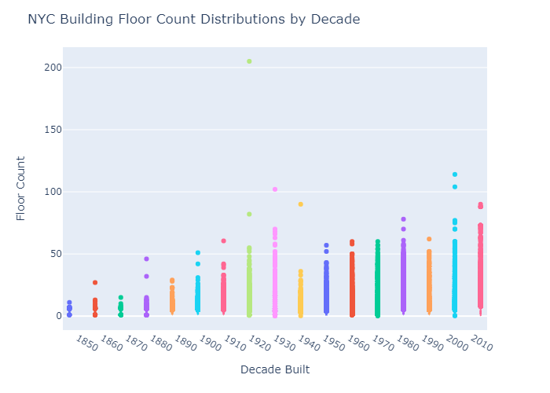

```python
fig3.write_image('fig3.png')
Image('fig3.png')
```

```python
#### Basic shape of the data
```

```python
fig4 = go.Figure()

fig4.add_trace(go.Histogram(
    x=df['year_built'],
    y=df['num_floors'],
    name='up to 1900',
    xbins=dict(
        start=1800,
        end=1900,
        size=5
    ),
    marker_color='yellow',
    opacity=0.75
))
fig4.add_trace(go.Histogram(
    x=df['year_built'],
    y=df['num_floors'],
    name='1900-1920',
    xbins=dict(
        start=1900,
        end=1920,
        size=5
    ),
    marker_color='lightblue',
    opacity=0.75
))
fig4.add_trace(go.Histogram(
    x=df['year_built'],
    y=df['num_floors'],
    name='1920-1940',
    xbins=dict(
        start=1920,
        end=1940,
        size=5
    ),
    marker_color='darkblue',
    opacity=0.75
))
fig4.add_trace(go.Histogram(
    x=df['year_built'],
    y=df['num_floors'],
    name='1940+',
    xbins=dict(
        start=1940,
        end=2020,
        size=5
    ),
    marker_color='green',
    opacity=0.75
))
fig4.update_layout(
    title_text='Floors built over time', # title of plot
    xaxis_title_text='Time', # xaxis label
    yaxis_title_text='Total Floors', # yaxis label
)
print()
```

```python
#fig4.show()
```

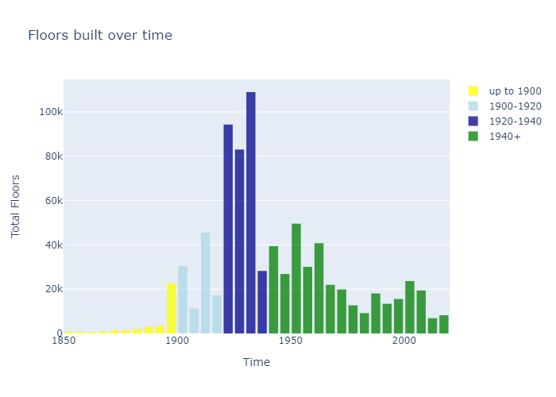

```python
fig4.write_image("fig4.png")
Image("fig4.png")
```

## Part 2: Datashader

Datashader is a library from Anaconda that does away with the need for binning data. It takes in all of your datapoints, and based on the canvas and range returns a pixel-by-pixel calculations to come up with the best representation of the data. In short, this completely eliminates the need for binning your data.

As an example, lets continue with our question above and look at a 2D histogram of YearBuilt vs NumFloors:

```python
yearbins = 200
floorbins = 200

yearBuiltCut = pd.cut(ny['yearbuilt'], np.linspace(ny['yearbuilt'].min(), ny['yearbuilt'].max(), yearbins))
numFloorsCut = pd.cut(ny['numfloors'], np.logspace(1, np.log(ny['numfloors'].max()), floorbins))

xlabels = np.floor(np.linspace(ny['yearbuilt'].min(), ny['yearbuilt'].max(), yearbins))
ylabels = np.floor(np.logspace(1, np.log(ny['numfloors'].max()), floorbins))

fig = go.FigureWidget(
    data = [
        go.Heatmap(z = ny.groupby([numFloorsCut, yearBuiltCut])['bbl'].count().unstack().fillna(0).values,
              colorscale = 'Greens', x = xlabels, y = ylabels)
    ]
)

fig
```

[output not shown]

Here is what the same plot would look like in datashader:

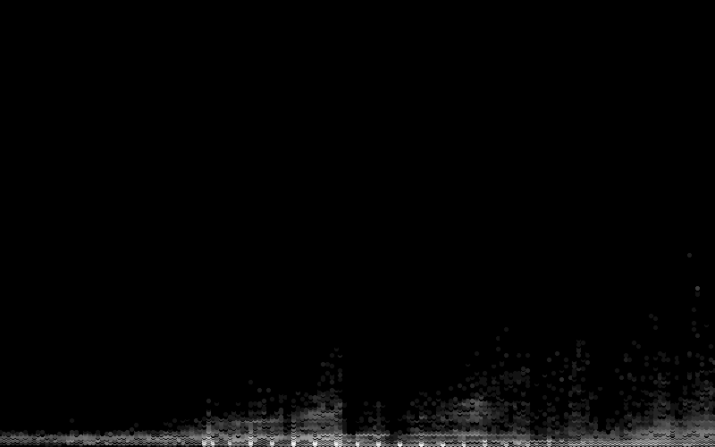

```python
cvs = ds.Canvas(800, 500, x_range = (ny['yearbuilt'].min(), ny['yearbuilt'].max()),
                                y_range = (ny['numfloors'].min(), ny['numfloors'].max()))
agg = cvs.points(ny, 'yearbuilt', 'numfloors')
view = tf.shade(agg, cmap = cm(Greys9), how='log')
export(tf.spread(view, px=2), 'yearvsnumfloors')
```

That's technically just a scatterplot, but the points are smartly placed and colored to mimic what one gets in a heatmap. Based on the pixel size, it will either display individual points, or will color the points of denser regions.

Datashader really shines when looking at geographic information. Here are the latitudes and longitudes of our dataset plotted out, giving us a map of the city colored by density of structures:

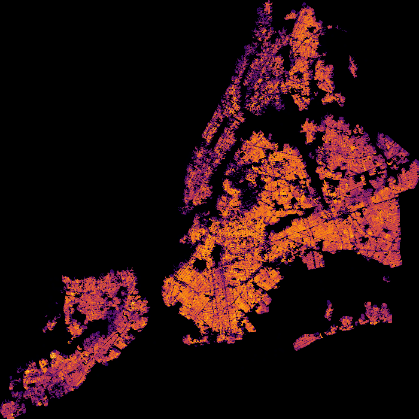

```python
NewYorkCity   = (( 913164.0,  1067279.0), (120966.0, 272275.0))
cvs = ds.Canvas(700, 700, *NewYorkCity)
agg = cvs.points(ny, 'xcoord', 'ycoord')
view = tf.shade(agg, cmap = cm(inferno), how='log')
export(tf.spread(view, px=2), 'firery')
```

Interestingly, since we're looking at structures, the large buildings of Manhattan show up as less dense on the map. The densest areas measured by number of lots would be single or multi family townhomes.

Unfortunately, Datashader doesn't have the best documentation. Browse through the examples from their [github repo](https://github.com/bokeh/datashader/tree/master/examples). I would focus on the [visualization pipeline](https://anaconda.org/jbednar/pipeline/notebook) and the [US Census](https://anaconda.org/jbednar/census/notebook) Example for the question below. Feel free to use my samples as templates as well when you work on this problem.

### Question

You work for a real estate developer and are researching underbuilt areas of the city. After looking in the [Pluto data dictionary](https://www1.nyc.gov/assets/planning/download/pdf/data-maps/open-data/pluto_datadictionary.pdf?v=17v1_1), you've discovered that all tax assessments consist of two parts: The assessment of the land and assessment of the structure. You reason that there should be a correlation between these two values: more valuable land will have more valuable structures on them (more valuable in this case refers not just to a mansion vs a bungalow, but an apartment tower vs a single family home). Deviations from the norm could represent underbuilt or overbuilt areas of the city. You also recently read a really cool blog post about [bivariate choropleth maps](http://www.joshuastevens.net/cartography/make-a-bivariate-choropleth-map/), and think the technique could be used for this problem.

Datashader is really cool, but it's not that great at labeling your visualization. Don't worry about providing a legend, but provide a quick explanation as to which areas of the city are overbuilt, which areas are underbuilt, and which areas are built in a way that's properly correlated with their land value.

```python
data = {
     'xcoord': ny['xcoord'],
     'ycoord': ny['ycoord'],
     'bldg_area': ny['bldgarea'],
     'bldg_assess': ny['assesstot']-ny['assessland'],
     'bldg_sq': (ny['assesstot']-ny['assessland']) / ny['bldgarea'],
     'land_area': ny['lotarea'],
     'land_assess': ny['assessland'],
     'land_sq': ny['assessland'] / ny['lotarea'],
}

df_out = pd.DataFrame(data)
df_out['bldg_land_rat'] = df_out['bldg_sq'] / df_out['land_sq']

df_out.head()
```

|  | xcoord | ycoord | bldg_area | bldg_assess | bldg_sq | land_area | land_assess | land_sq | bldg_land_rat |
| --- | --- | --- | --- | --- | --- | --- | --- | --- | --- |
| 0 | 982211.0 | 171707.0 | 3648.0 | 204300.0 | 56.003289 | 1613.0 | 146250.0 | 90.669560 | 0.617664 |
| 1 | 1026895.0 | 225880.0 | 3276.0 | 66660.0 | 20.347985 | 5000.0 | 12240.0 | 2.448000 | 8.312086 |
| 2 | 1004527.0 | 177269.0 | 2814.0 | 16260.0 | 5.778252 | 3000.0 | 18120.0 | 6.040000 | 0.956664 |
| 3 | 1004804.0 | 166580.0 | 973.0 | 16920.0 | 17.389517 | 1800.0 | 7680.0 | 4.266667 | 4.075668 |
| 4 | 1004784.0 | 166579.0 | 938.0 | 21600.0 | 23.027719 | 1800.0 | 8160.0 | 4.533333 | 5.079644 |

#### Remove NA values

Convert Infinite values (often division by zero) to NaN and drop.

```python
# https://stackoverflow.com/questions/45745085/python-pandas-how-to-remove-nan-and-inf-values/45745154
print(df_out.info())
df_out = df_out.replace([np.inf, -np.inf], np.nan).dropna(axis=0)
print(df_out.info())
```

```
<class 'pandas.core.frame.DataFrame'>
Int64Index: 811684 entries, 0 to 859171
Data columns (total 9 columns):
 #   Column         Non-Null Count   Dtype
---  ------         --------------   -----
 0   xcoord         811380 non-null  float64
 1   ycoord         811380 non-null  float64
 2   bldg_area      811668 non-null  float64
 3   bldg_assess    811684 non-null  float64
 4   bldg_sq        811623 non-null  float64
 5   land_area      811684 non-null  float64
 6   land_assess    811684 non-null  float64
 7   land_sq        811684 non-null  float64
 8   bldg_land_rat  811244 non-null  float64
dtypes: float64(9)
memory usage: 61.9 MB
None
<class 'pandas.core.frame.DataFrame'>
Int64Index: 809585 entries, 0 to 859171
Data columns (total 9 columns):
 #   Column         Non-Null Count   Dtype
---  ------         --------------   -----
 0   xcoord         809585 non-null  float64
 1   ycoord         809585 non-null  float64
 2   bldg_area      809585 non-null  float64
 3   bldg_assess    809585 non-null  float64
 4   bldg_sq        809585 non-null  float64
 5   land_area      809585 non-null  float64
 6   land_assess    809585 non-null  float64
 7   land_sq        809585 non-null  float64
 8   bldg_land_rat  809585 non-null  float64
dtypes: float64(9)
memory usage: 61.8 MB
None
```

#### Create categorical values

Since this question explicitly focuses on the charting an unknown relationship between two variables, we'll pay more attention to normalization. We don't necessarily want to show a 1:1 relationship nor do we want a normal curve, as might be the case if very few areas were overbuilt (we don't know the distribution in NYC). To avoid this, we normalize the individual variables.

Exploring the distribution, we find a very large outlier and many larger numbers. We don't know what the graph is being used to do (for instance we may need to identify newly developing land or properties with specific zoning or financial situations). We'll should leave the values as is or squash them, but as a first run trying datashader, we'll remove the outliers.

```
[885.0, 986.0, 1001.0, 1111.0, 1114.0, 1137.0, 1222.0, 1253.0, 1390.0, 1516.0, 1697.0, 1698.0, 2171.0, 2173.0, 2380.0, 2496.0, 2624.0, 2645.0, 5424.0, 140930.0]
```

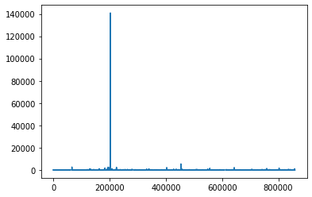

```python
print(sorted(df_out['bldg_land_rat'].round(0))[-20:])
df_out.bldg_land_rat.describe()
plt.plot(df_out['bldg_land_rat'])
plt.show()
```

#### Remove outliers, Inf and NA, Scale and Recalculate Ratio

```python
#https://stackoverflow.com/questions/23199796/detect-and-exclude-outliers-in-pandas-data-frame
#https://stackoverflow.com/questions/49800045/python-fast-way-of-minmax-scaling-an-array
#https://chrisalbon.com/python/data_wrangling/pandas_normalize_column/

# Remove outliers
df_in = df_out[((df_out.bldg_sq - df_out.bldg_sq.mean()) / df_out.bldg_sq.std()).abs() < 3]
df_in = df_in[((df_in.land_sq - df_in.land_sq.mean()) / df_in.land_sq.std()).abs() < 3]
# Scale 0 to 1
def quick_scale(x):
    mn, mx = x.min(), x.max()
    return (x - mn) / (mx - mn)
df_in.bldg_sq = quick_scale(df_in.bldg_sq)
df_in.land_sq = quick_scale(df_in.land_sq)
# Recalculate bldg to land sq ratio
df_in.bldg_land_rat = df_in.bldg_sq / df_in.land_sq
df_in.bldg_land_rat.describe()
```

```
count    8.087750e+05
mean              inf
std               NaN
min      0.000000e+00
25%      5.362977e-02
50%      8.334821e-02
75%      1.212786e-01
max               inf
Name: bldg_land_rat, dtype: float64
```

```python
# Remove Inf and NaN
df_in = df_in.replace([np.inf, -np.inf], np.nan)
print(df_in.isna().sum().sum())
df_in = df_in.dropna(axis=0)
```

```
1
```

```
[19.0, 19.0, 20.0, 23.0, 23.0, 25.0, 26.0, 28.0, 29.0, 30.0, 32.0, 35.0, 45.0, 48.0, 50.0, 50.0, 54.0, 57.0, 60.0, 125.0]
```

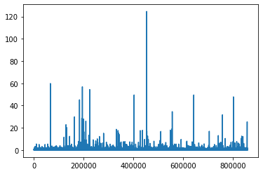

```
count    808774.000000
mean          0.109960
std           0.291334
min           0.000000
25%           0.053630
50%           0.083348
75%           0.121279
max         124.652927
Name: bldg_land_rat, dtype: float64
```

```python
# View new building to land square foot value ratio data
print(sorted(df_in.bldg_land_rat.round(0))[-20:])
plt.plot(df_in.bldg_land_rat)
plt.show()
df_in.bldg_land_rat.describe()
```

```python
#df_in['bldg_rating'] = pd.qcut(df_in['bldg_sq'], q=3, labels=['C','B','A'], precision=0)
#df_in['land_rating'] = pd.qcut(df_in['land_sq'], q=3, labels=['C','B','A'], precision=0)
#df_in['bldg_land_rating'] = df_in['bldg_rating'].str.cat(df_in['land_rating'])

# Write an opinionated building to land ratio since we lost precision creating categorical labels
# We care more about the distribution
df_in['build_score'] = pd.Categorical(pd.qcut(df_in['bldg_land_rat'], q=6, labels=['F','E','D','C','B','A'], precision=0))
df_in.head()
```

|  | xcoord | ycoord | bldg_area | bldg_assess | bldg_sq | land_area | land_assess | land_sq | bldg_land_rat | build_score |
| --- | --- | --- | --- | --- | --- | --- | --- | --- | --- | --- |
| 0 | 982211.0 | 171707.0 | 3648.0 | 204300.0 | 0.001994 | 1613.0 | 146250.0 | 0.141639 | 0.014079 | F |
| 1 | 1026895.0 | 225880.0 | 3276.0 | 66660.0 | 0.000725 | 5000.0 | 12240.0 | 0.003815 | 0.189943 | A |
| 2 | 1004527.0 | 177269.0 | 2814.0 | 16260.0 | 0.000206 | 3000.0 | 18120.0 | 0.009426 | 0.021828 | F |
| 3 | 1004804.0 | 166580.0 | 973.0 | 16920.0 | 0.000619 | 1800.0 | 7680.0 | 0.006656 | 0.093032 | C |
| 4 | 1004784.0 | 166579.0 | 938.0 | 21600.0 | 0.000820 | 1800.0 | 8160.0 | 0.007072 | 0.115939 | B |

```python
output_notebook()
color_key= {'A':'#FF0000', 'B':'#ff6600', 'C':'#FFCC00', 'D':'#FFFF00', 'E':'#ccff00', 'F':'#00FF00' }
cat_legend = create_categorical_legend(color_key)
aliases = {'A':'Very Overbuilt',
           'B':'Somehwat Overbuilt',
           'C':'Maybe Overbuilt',
           'D':'Maybe Underbuilt',
           'E':'Somehwat Underbuilt',
           'F':'Very Underbuilt' }
cat_legend_with_aliases = create_categorical_legend(color_key, aliases=aliases)
```

[interactive chart not shown]

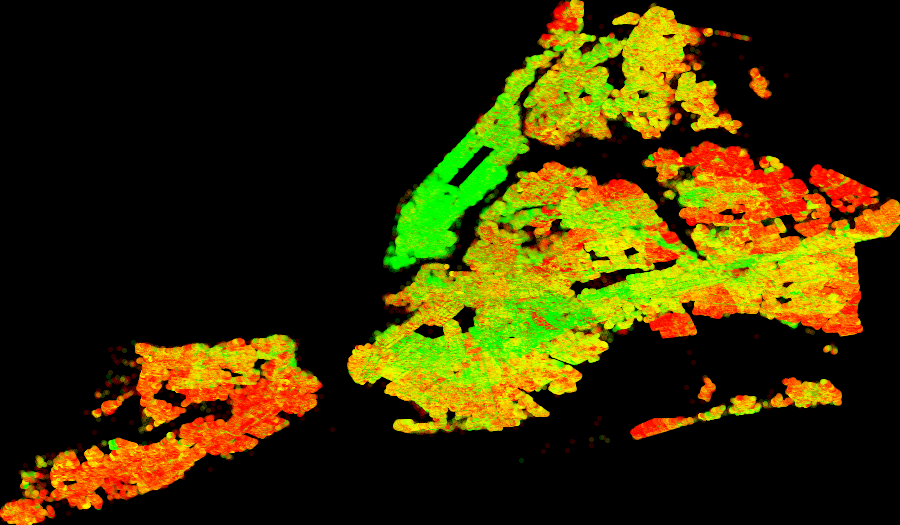

```python
# Code from inline examples, https://examples.pyviz.org/census/census.html
# https://matplotlib.org/3.1.0/tutorials/colors/colormaps.html
# https://stackoverflow.com/questions/4161369/html-color-codes-red-to-yellow-to-green
# https://anaconda.org/jbednar/legends/notebook
NewYorkCity2   = ((913164.0,  1067279.0), (120966.0, 272275.0))
plot_width  = int(900)
plot_height = int(plot_width*7.0/12)
cvs2 = ds.Canvas(plot_width, plot_height, *NewYorkCity2)
agg2 = cvs2.points(df_in, 'xcoord', 'ycoord', ds.count_cat('build_score'))
view2 = tf.shade(agg2, color_key=color_key, how='log')
show(cat_legend_with_aliases)
export(tf.spread(view2, px=2), 'builds')
```

The red to green legend is meant to reflect a high to low building to land value ratio. The map shows a low ratio in Manhattan and a high ratio further out into the boroughs. The legend naively reflects this as a function of overbuiltness to underbuiltness.

Yet, after viewing the visualization, it appears that deviations from the norm in building to land ratio may not be adaquate to represent overbuilding or underbuilding. These instead may be driven more by the value of the land. For instance, by looking at density and land value, it may make be possible to explain Manhattan's low building to land square foot assessment ratio and also reflect that this is not a function of being overbuilt (if the land value is very high and the building size is reduced by zoning designed to decrease high rises in Manhattan). In retrospect, we should be doing more data analysis before creating this map explaing over and underbuilt areas.